# Group4-KKT,KYJ,KYR,SJH

# North America

# N.A-Cities that change of the temperature is significant

#3-15 Canada-Montreal (overall graph of Montreal’s temperature from 1860 to 2013)

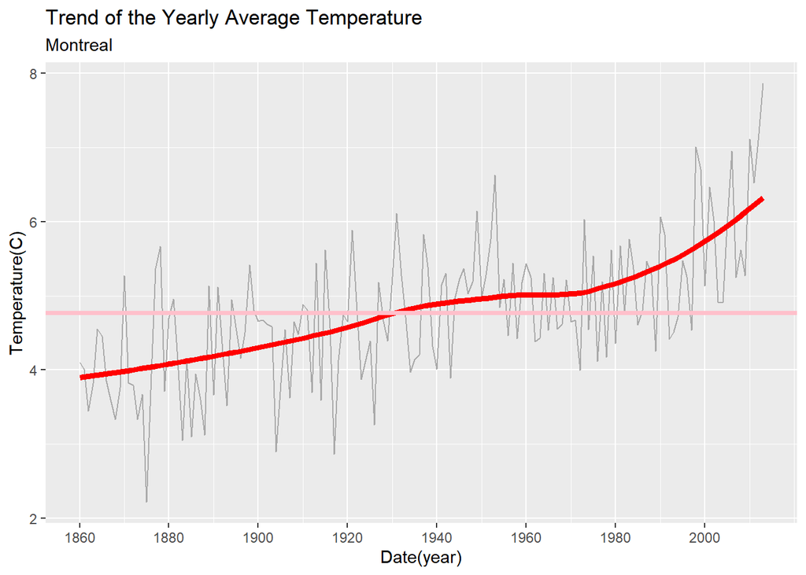

```r
#Kim Yoon Ji
#Extract only Montreal temperature data from 'yclean' and remove NA values
montreal <- yclean %>% filter(City=="Montreal") %>% na.omit()

#Summarise annual average temperature and make a graph of it
#Dark grey line represents the annual average temperature of Montreal, pink line shows average temperature throughout the period(1860~2013), and red line is the reference line of the annual average temperature.
montreal %>% group_by(year) %>% summarise(ave = mean(AverageTemperature)) %>% na.omit() %>%
  ggplot() + geom_line(col="dark grey") + aes(x=year, y=ave) + geom_smooth(col='Red', se=F, lwd=1.7)+
  geom_hline(yintercept=mean(montreal$AverageTemperature), col='pink', lwd=1.3)+
  labs(title = "Trend of the Yearly Average Temperature", subtitle="Montreal", x= "Date(year)", y="Temperature(C)")+
  scale_x_continuous(breaks = seq(1860, 2013, 20))
```

1)From 1980 to 1920, the temperature seems to rise quite rapidly and consistently.

2)From 1920 to 1970, the temperature seems to rise slightly compared to other periods or have no significant increase.

3)From 1970 to 2013, the temperature increases drastically, even more than 1980~2013. In 2000, Canada ranked ninth out of 186 countries in terms of per capita greenhouse gas emissions, and in 2005, it ranked eighth and in 2009, it ranked seventh. Even more, Canada was second for per capita emission. This fact can explain why the temperature rise dramatically throughout 1970 to 2013. Though Canada has very low popluation density, it has very high emission. Therefore, unlike other countries that has suffered from urbanization and population explosion, high rate of emission could be Canada’s main reason for the temperature increase.

# Canada-Montreal (temperature graph by season)

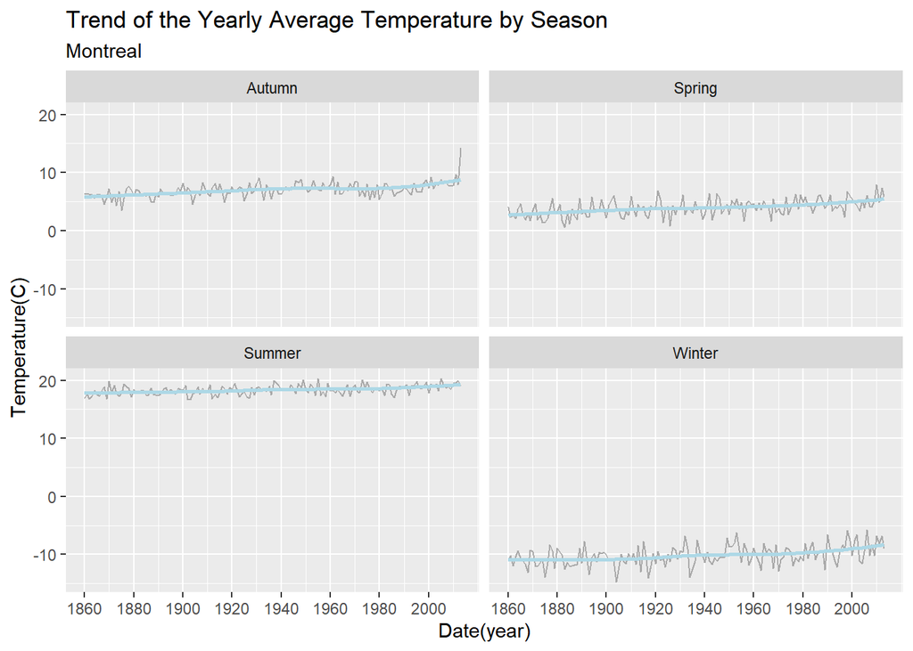

```r
#Kim Yoon Ji
#Similar graph with above, but faceted with seasons (3~5: Spring, 6~8: Summer, 9~11: Autumn, 12~2: Winter)
montreal %>% group_by(season, year) %>% summarise(ave = mean(AverageTemperature)) %>% na.omit() %>%
  ggplot() + geom_line(col="dark grey") + aes(x=year, y=ave) + geom_smooth(col='light blue', se=F)+
  labs(title = "Trend of the Yearly Average Temperature by Season", subtitle="Montreal", x= "Date(year)", y="Temperature(C)")+
  scale_x_continuous(breaks = seq(1860, 2013, 20))+
  facet_wrap(~season)
```

#3-16 Canada-Toronto (overall graph of Toronto’s temperature from 1860 to 2013)

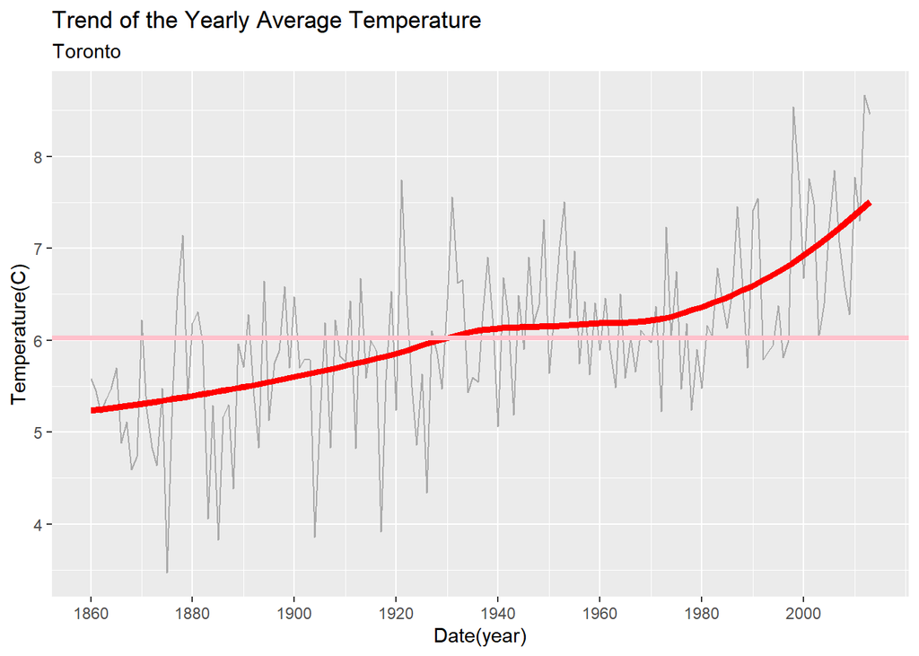

```r
#Kim Yoon Ji
#Extract only Toronto temperature data from 'yclean' and remove NA values
toronto <- yclean %>% filter(City=="Toronto") %>% na.omit()

#Summarise annual average temperature and make a graph of it
#Dark grey line represents the annual average temperature of Toronto, pink line shows average temperature throughout the period(1860~2013), and red line is the reference line of the annual average temperature.
toronto %>% group_by(year) %>% summarise(ave = mean(AverageTemperature)) %>% na.omit() %>%
  ggplot() + geom_line(col="dark grey") + aes(x=year, y=ave) + geom_smooth(col='Red', se=F, lwd=1.7)+
  geom_hline(yintercept=mean(toronto$AverageTemperature), col='pink', lwd=1.3)+
  labs(title = "Trend of the Yearly Average Temperature", subtitle="Toronto", x= "Date(year)", y="Temperature(C)")+
  scale_x_continuous(breaks = seq(1860, 2013, 20))
```

# Canada-Toronto (temperature graph by season)

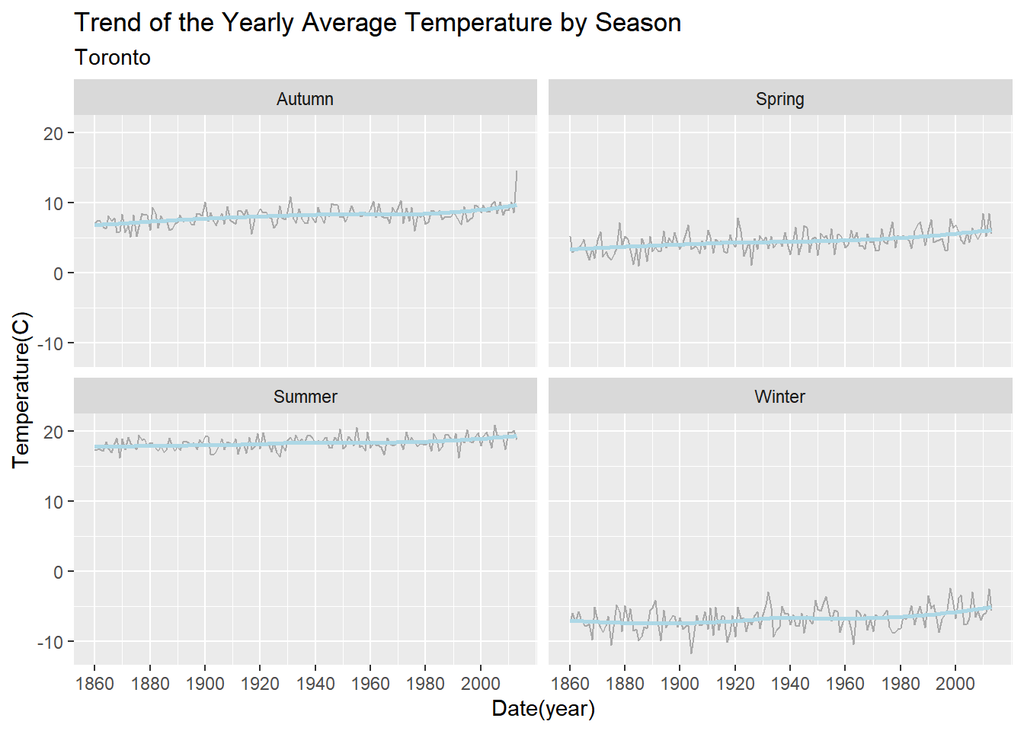

```r
#Kim Yoon Ji
#Similar graph with above, but faceted with seasons (3~5: Spring, 6~8: Summer, 9~11: Autumn, 12~2: Winter)
toronto %>% group_by(season, year) %>% summarise(ave = mean(AverageTemperature)) %>% na.omit() %>%
  ggplot() + geom_line(col="dark grey") + aes(x=year, y=ave) + geom_smooth(col='light blue', se=F)+
  labs(title = "Trend of the Yearly Average Temperature by Season", subtitle="Toronto", x= "Date(year)", y="Temperature(C)")+
  scale_x_continuous(breaks = seq(1860, 2013, 20))+
  facet_wrap(~season)
```

Since Toronto is geographically close to Montreal and is same Country with Montreal, the backgroud and cause of the temperature change is simliar to Montreal.

#3-17 U.S.-Chicago (overall graph of Chicago’s temperature from 1860 to 2013)

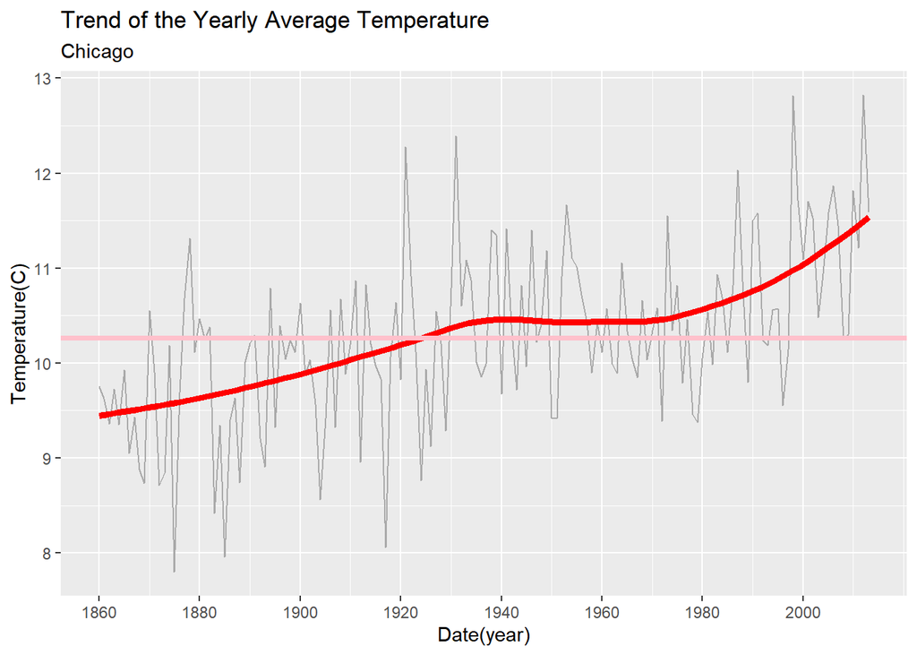

```r
#Kim Yoon Ji
#Extract only Chicago temperature data from 'yclean' and remove NA values
chicago <- yclean %>% filter(City=="Chicago") %>% na.omit()

#Summarise annual average temperature and make a graph of it
#Dark grey line represents the annual average temperature of Chicago, pink line shows average temperature throughout the period(1860~2013), and red line is the reference line of the annual average temperature.
chicago %>% group_by(year) %>% summarise(ave = mean(AverageTemperature)) %>% na.omit() %>%
  ggplot() + geom_line(col="dark grey") + aes(x=year, y=ave) + geom_smooth(col='Red', se=F, lwd=1.7)+
  geom_hline(yintercept=mean(chicago$AverageTemperature), col='pink', lwd=1.3)+
  labs(title = "Trend of the Yearly Average Temperature", subtitle="Chicago", x= "Date(year)", y="Temperature(C)")+
  scale_x_continuous(breaks = seq(1860, 2013, 20))
```

# U.S.-Chicago (temperature graph by season)

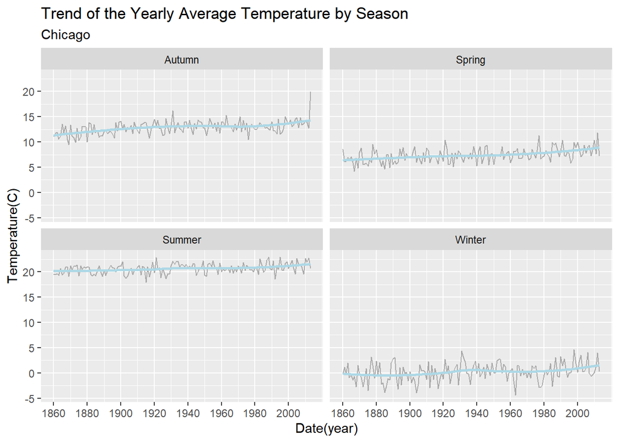

```r
#Kim Yoon Ji
#Similar graph with above, but faceted with seasons (3~5: Spring, 6~8: Summer, 9~11: Autumn, 12~2: Winter)
chicago %>% group_by(season, year) %>% summarise(ave = mean(AverageTemperature)) %>% na.omit() %>%
  ggplot() + geom_line(col="dark grey") + aes(x=year, y=ave) + geom_smooth(col='light blue', se=F)+
  labs(title = "Trend of the Yearly Average Temperature by Season", subtitle="Chicago", x= "Date(year)", y="Temperature(C)")+
  scale_x_continuous(breaks = seq(1860, 2013, 20))+
  facet_wrap(~season)
```

Tempreature of Chicago increased in Autumn and Spring more than Summer and Winter. Also, the temperature in winter tends to fluctuate more than other seasons.

# South America

# S.A-Cities that change of the temperature is significant

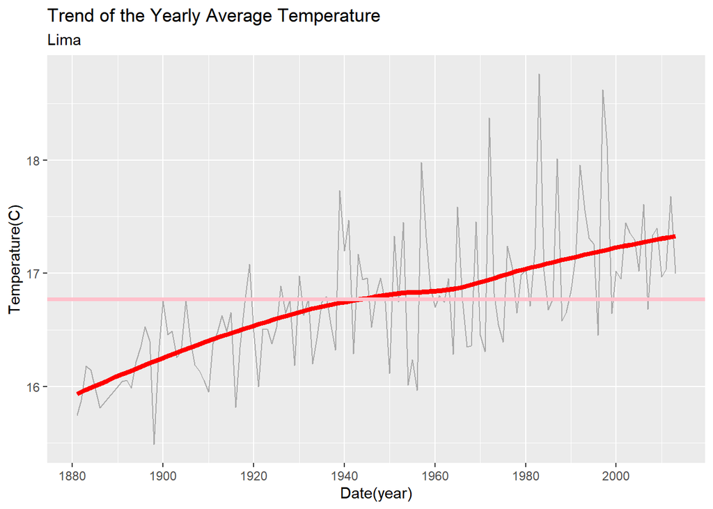

```r
#Kim Yoon Ji
#Extract only Lima temperature data from 'yclean' and remove NA values
lima <- yclean %>% filter(City=="Lima") %>% na.omit()

#Summarise annual average temperature and make a graph of it
#Dark grey line represents the annual average temperature of Lima, pink line shows average temperature throughout the period(1860~2013), and red line is the reference line of the annual average temperature.
lima %>% group_by(year) %>% summarise(ave = mean(AverageTemperature)) %>% na.omit() %>%
  ggplot() + geom_line(col="dark grey") + aes(x=year, y=ave) + geom_smooth(col='Red', se=F, lwd=1.7)+
  geom_hline(yintercept=mean(lima$AverageTemperature), col='pink', lwd=1.3)+
  labs(title = "Trend of the Yearly Average Temperature", subtitle="Lima", x= "Date(year)", y="Temperature(C)")+
  scale_x_continuous(breaks = seq(1860, 2013, 20))
```

Peru is one of the countries highly vulnerable to climate change, with many climate vulnerability characteristics recognized in the 1992 United Nations Framework Convention on Climate Change (UNFCCC), including low coastal zones; arid and semi-arid areas; exposure to floods and zones prone to natural disasters. The complex geography added to the deforestation of some areas was associated with altitudinal changes in habitat from vectors of Malaria and Chagas disease. For this reason, unlike cities which have encountered industrialization or urbanization have specific point that have significant changes in temperature graph, Lima’s temperature rises constantly because of its complicate geographic circumstance.

# Lima (temperature graph by season)

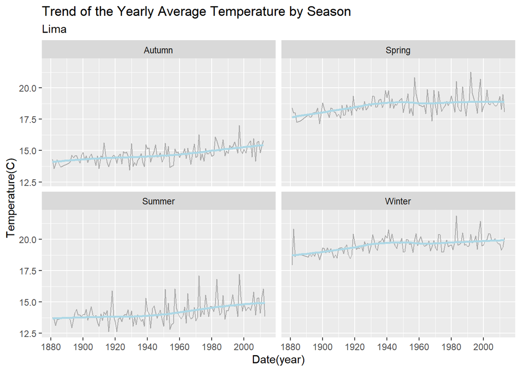

```r
#Kim Yoon Ji
#Similar graph with above, but faceted with seasons (3~5: Spring, 6~8: Summer, 9~11: Autumn, 12~2: Winter)
lima %>% group_by(season, year) %>% summarise(ave = mean(AverageTemperature)) %>% na.omit() %>%
  ggplot() + geom_line(col="dark grey") + aes(x=year, y=ave) + geom_smooth(col='light blue', se=F)+
  labs(title = "Trend of the Yearly Average Temperature by Season", subtitle="Lima", x= "Date(year)", y="Temperature(C)")+
  scale_x_continuous(breaks = seq(1860, 2013, 20))+
  facet_wrap(~season)
```

When we look at the graph of Lima by seasons, in Autumn and Summer, the temperature remained almost same until 1950s, but rose a bit after then. And in Spring and Winter, the temperature rose until 1940s and remained its status quo after then.

#3-19 Brazil-Sao Paulo (overall graph of S찾o Paulo’s temperatrue from 1860 to 2013)

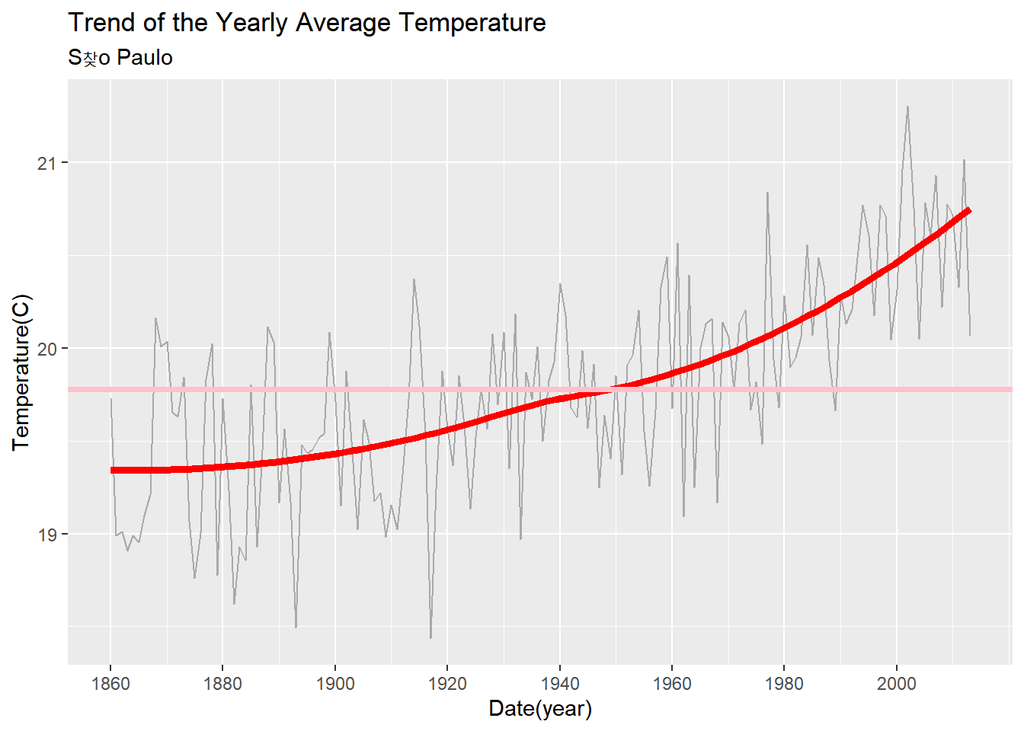

```r
#Kim Yoon Ji
#Extract only S찾o Paulo's temperature data from 'yclean' and remove NA values
sp <- yclean %>% filter(City==part4_cities[5]) %>% na.omit()

#Summarise annual average temperature and make a graph of it
#Dark grey line represents the annual average temperature of S찾o Paulo, pink line shows average temperature throughout the period(1860~2013), and red line is the reference line of the annual average temperature.
sp %>% group_by(year) %>% summarise(ave = mean(AverageTemperature)) %>% na.omit() %>%
  ggplot() + geom_line(col="dark grey") + aes(x=year, y=ave) + geom_smooth(col='Red', se=F, lwd=1.7)+
  geom_hline(yintercept=mean(sp$AverageTemperature), col='pink', lwd=1.3)+
  labs(title = "Trend of the Yearly Average Temperature", subtitle="S찾o Paulo", x= "Date(year)", y="Temperature(C)")+
  scale_x_continuous(breaks = seq(1860, 2013, 20))
```

# Brazil-Sao Paulo (temperature graph by season)

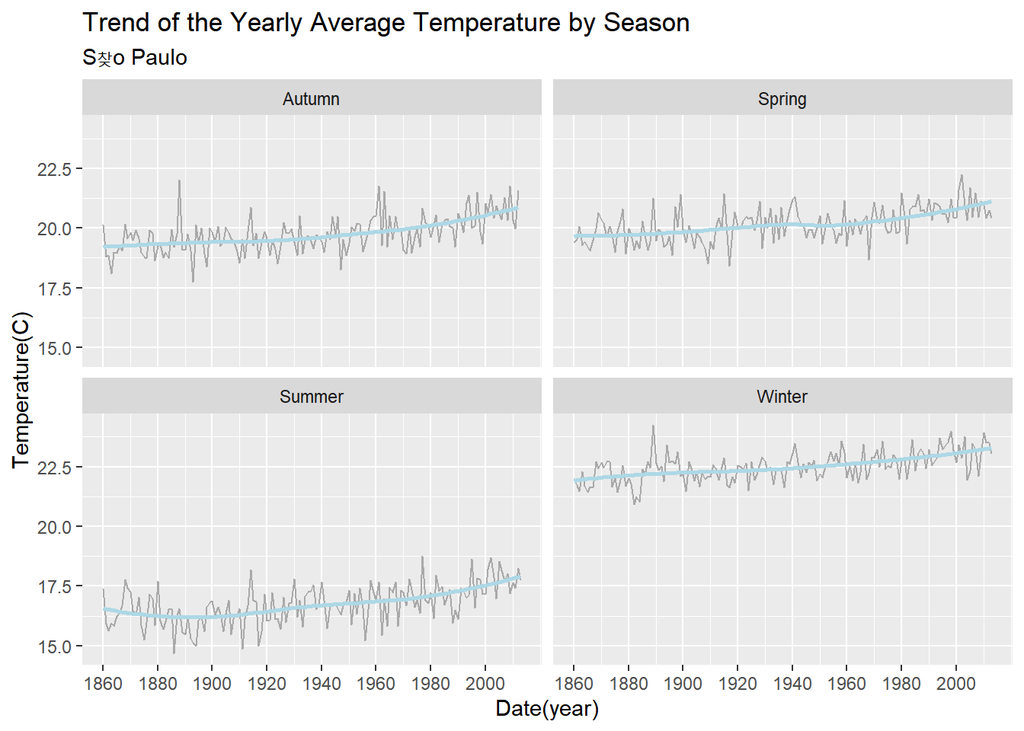

```r
#Kim Yoon Ji
#Similar graph with above, but faceted with seasons (3~5: Spring, 6~8: Summer, 9~11: Autumn, 12~2: Winter)
sp %>% group_by(season, year) %>% summarise(ave = mean(AverageTemperature)) %>% na.omit() %>%
  ggplot() + geom_line(col="dark grey") + aes(x=year, y=ave) + geom_smooth(col='light blue', se=F)+
  labs(title = "Trend of the Yearly Average Temperature by Season", subtitle="S찾o Paulo", x= "Date(year)", y="Temperature(C)")+
  scale_x_continuous(breaks = seq(1860, 2013, 20))+
  facet_wrap(~season)
```

#3-20 Brazil-Rio de Janeiro (overall graph of Rio de Janeiro’s temperatrue from 1860 to 2013)

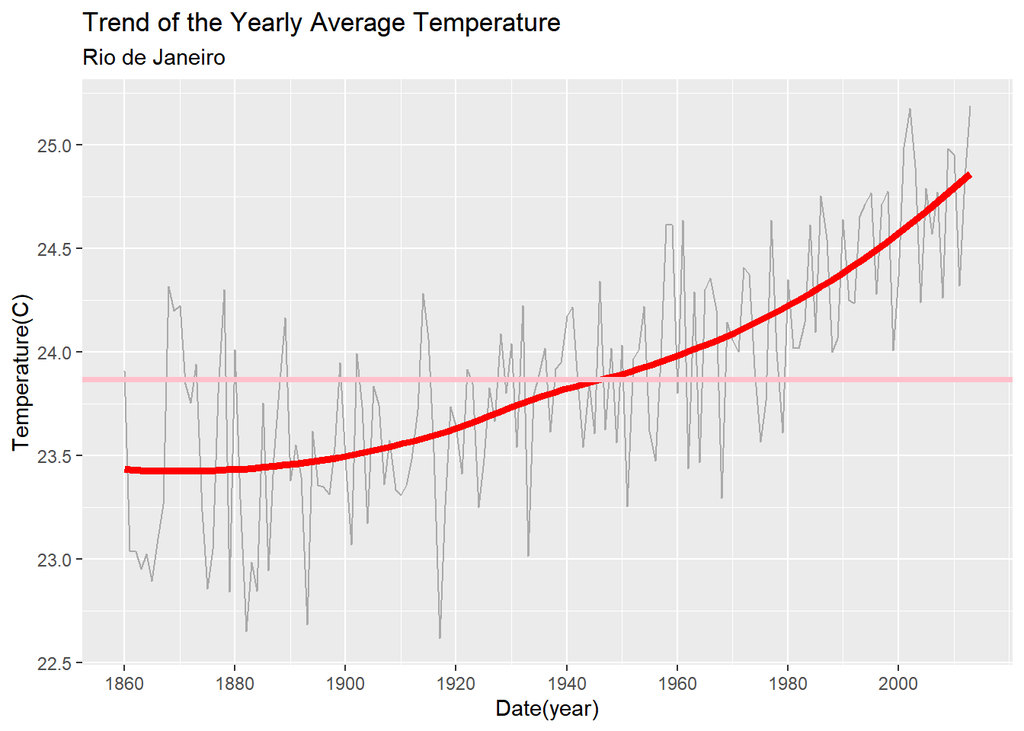

```r
#Kim Yoon Ji
#Extract only Rio de Janeiro's temperature data from 'yclean' and remove NA values
rio <- yclean %>% filter(City=="Rio De Janeiro") %>% na.omit()

#Summarise annual average temperature and make a graph of it
#Dark grey line represents the annual average temperature of Rio de Janeiro, pink line shows average temperature throughout the period(1860~2013), and red line is the reference line of the annual average temperature.
rio %>% group_by(year) %>% summarise(ave = mean(AverageTemperature)) %>% na.omit() %>%
  ggplot() + geom_line(col="dark grey") + aes(x=year, y=ave) + geom_smooth(col='Red', se=F, lwd=1.7)+
  geom_hline(yintercept=mean(rio$AverageTemperature), col='pink', lwd=1.3)+
  labs(title = "Trend of the Yearly Average Temperature", subtitle="Rio de Janeiro", x= "Date(year)", y="Temperature(C)")+
  scale_x_continuous(breaks = seq(1860, 2013, 20))
```

# Brazil-Rio de Janeiro (temperature graph by season)

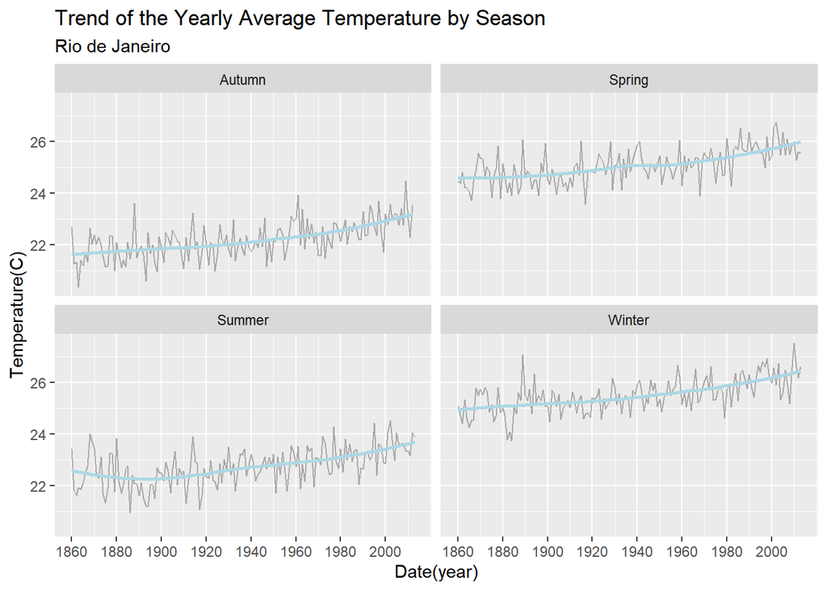

```r
#Kim Yoon Ji
#Similar graph with above, but faceted with seasons (3~5: Spring, 6~8: Summer, 9~11: Autumn, 12~2: Winter)
rio %>% group_by(season, year) %>% summarise(ave = mean(AverageTemperature)) %>% na.omit() %>%
  ggplot() + geom_line(col="dark grey") + aes(x=year, y=ave) + geom_smooth(col='light blue', se=F)+
  labs(title = "Trend of the Yearly Average Temperature by Season", subtitle="Rio de Janeiro", x= "Date(year)", y="Temperature(C)")+
  scale_x_continuous(breaks = seq(1860, 2013, 20))+
  facet_wrap(~season)
```

As Brazil industrialized roughly from 1900s, the temperature graphs show the increase from 1900s. Though the industrialization is a factor of climate change, urban expansion is at least partly responsible. Between 1960 and 2015, Rio?셲 greater metropolitan area grew by roughly 7 million people and has seen development spread into areas that used to be rural or forested. Since common building materials like asphalt, steel, concrete, and brick retain more heat than vegetation, land development elevates surface and, to a lesser degree, air temperatures. Meanwhile, the vehicles, factories, and air conditioning units that come with urbanization pump even more heat into the urban atmosphere. Therefore, increased humaon activity due to population explosion and the consequence emission and heat can be the significant reason for Rio de Janeiro’s climate change. S찾o Paulo is also the city of Brazil and its geographical location is close to Rio de Janeiro, the reason for its climate change might not be different from Rio de Janeiro’s.

# Africa

# Africa-Cities that change of the temperature is significant

# 3-21 Cairo

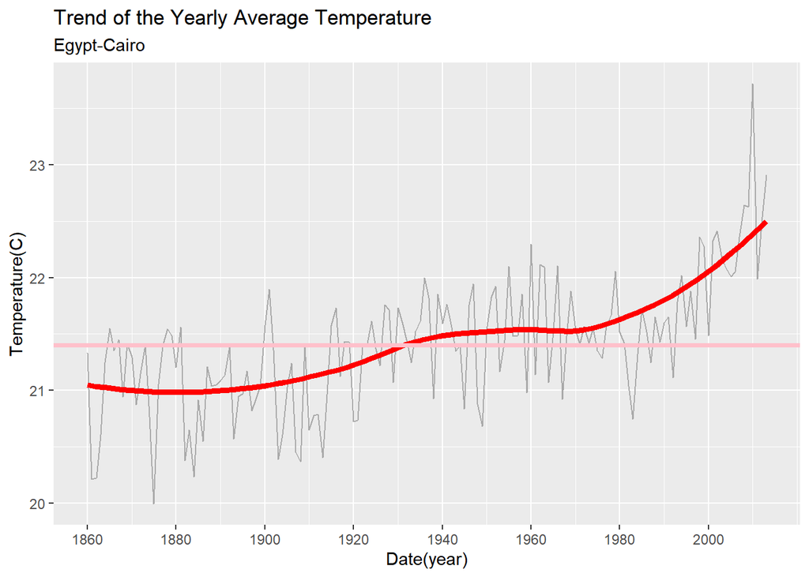

```r
# KIM KYU TAE
# Cairo

city1 <- yclean %>% filter(City==part1_cities[15]) %>% na.omit()
city1 %>% group_by(year) %>% summarise(ave = mean(AverageTemperature)) %>% na.omit() %>%
  ggplot() + geom_line(col="dark grey") + aes(x=year, y=ave) + geom_smooth(col='Red', se=F, lwd=1.7)+
  geom_hline(yintercept=mean(city1$AverageTemperature), col='pink', lwd=1.3)+
  labs(title = "Trend of the Yearly Average Temperature", subtitle="Egypt-Cairo", x= "Date(year)", y="Temperature(C)")+
  scale_x_continuous(breaks = seq(1860, 2013, 20))
```

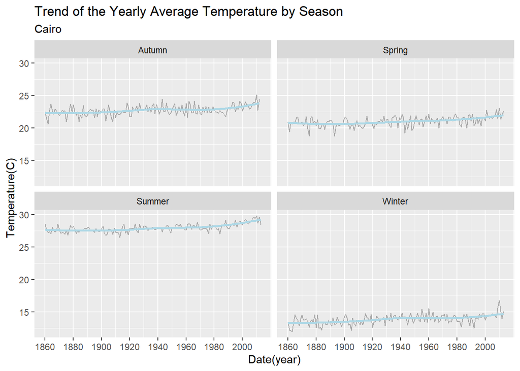

```r
city1 %>% group_by(season, year) %>% summarise(ave = mean(AverageTemperature)) %>% na.omit() %>%
  ggplot() + geom_line(col="dark grey") + aes(x=year, y=ave) + geom_smooth(col='light blue', se=F)+
  labs(title = "Trend of the Yearly Average Temperature by Season", subtitle="Cairo", x= "Date(year)", y="Temperature(C)")+
  scale_x_continuous(breaks = seq(1860, 2013, 20))+
  facet_wrap(~season)
```

The capital of Egypt. After World War I, light industries such as spinning and food processing developed. After World War II, heavy industries such as steel, shipbuilding, railway vehicles and chemical fertilizers, petroleum refining and petrochemical industries were also developed, connecting Suez’s refinery and pipeline. It is located on the right side of the Nile River, about 25 kilometers south of the southern tip of the Nile Delta. The city stretches from the island of Gejira, which has a loading island, to the left side of the river, and is the largest city in the Arab world and the continent of Africa. The average temperature in January is 12.7°C, the average temperature in August is 27.7°C, and the average annual precipitation is 25mm. Since it is a city next to the river, the average temperature varies greatly from month to month. (Domestic-Nail River Side)

# 3-22 Kano

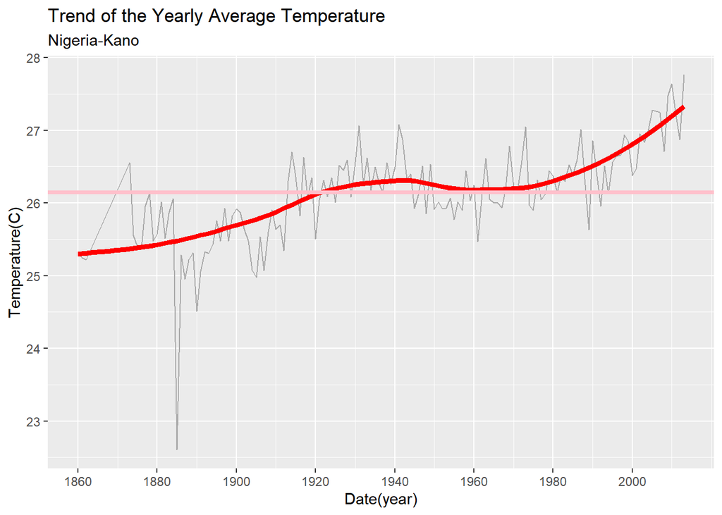

```r
# KIM KYU TAE
# Kano

city2 <- yclean %>% filter(City==part2_cities[21]) %>% na.omit()
city2 %>% group_by(year) %>% summarise(ave = mean(AverageTemperature)) %>% na.omit() %>%
  ggplot() + geom_line(col="dark grey") + aes(x=year, y=ave) + geom_smooth(col='Red', se=F, lwd=1.7)+
  geom_hline(yintercept=mean(city2$AverageTemperature), col='pink', lwd=1.3)+
  labs(title = "Trend of the Yearly Average Temperature", subtitle="Nigeria-Kano", x= "Date(year)", y="Temperature(C)")+
  scale_x_continuous(breaks = seq(1860, 2013, 20))
```

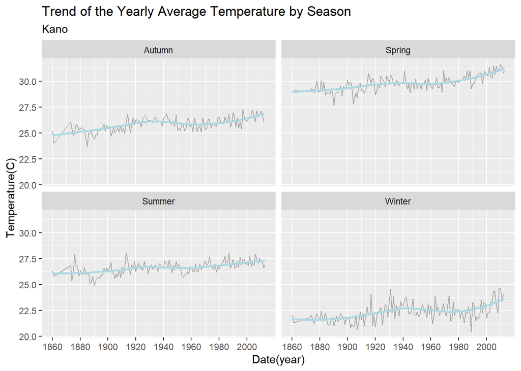

```r
city2 %>% group_by(season, year) %>% summarise(ave = mean(AverageTemperature)) %>% na.omit() %>%
  ggplot() + geom_line(col="dark grey") + aes(x=year, y=ave) + geom_smooth(col='light blue', se=F)+
  labs(title = "Trend of the Yearly Average Temperature by Season", subtitle="Kano", x= "Date(year)", y="Temperature(C)")+
  scale_x_continuous(breaks = seq(1860, 2013, 20))+
  facet_wrap(~season)
```

A capital of the state of Cano, Nigeria (newly established in 1968). An economic-cultural center city in northern Nigeria. There’s an international airport. It’s connected to various routes. New towns outside the fortress include African residential areas, commercial and industrial zones. In the surrounding areas, agricultural livestock such as peanuts, cotton, and livestock are active, and light industries such as food, leather, and textiles have been developed based on these primary products. The rise in temperature, which had slowed since the creation of Cano State in 1968, has soared. (Domestic)

# 3-23 Harare

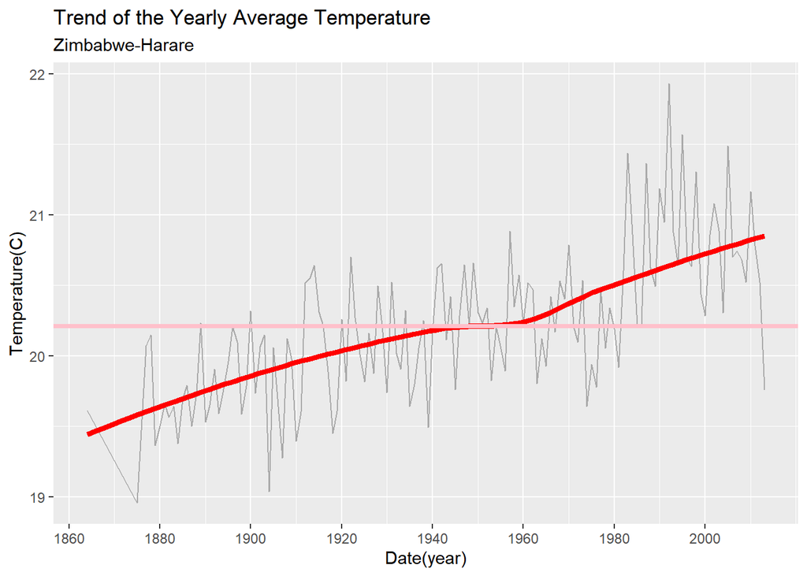

```r
# KIM KYU TAE
# Harare

city3 <- yclean %>% filter(City==part2_cities[9]) %>% na.omit()
city3 %>% group_by(year) %>% summarise(ave = mean(AverageTemperature)) %>% na.omit() %>%
  ggplot() + geom_line(col="dark grey") + aes(x=year, y=ave) + geom_smooth(col='Red', se=F, lwd=1.7)+
  geom_hline(yintercept=mean(city3$AverageTemperature), col='pink', lwd=1.3)+
  labs(title = "Trend of the Yearly Average Temperature", subtitle="Zimbabwe-Harare", x= "Date(year)", y="Temperature(C)")+
  scale_x_continuous(breaks = seq(1860, 2013, 20))
```

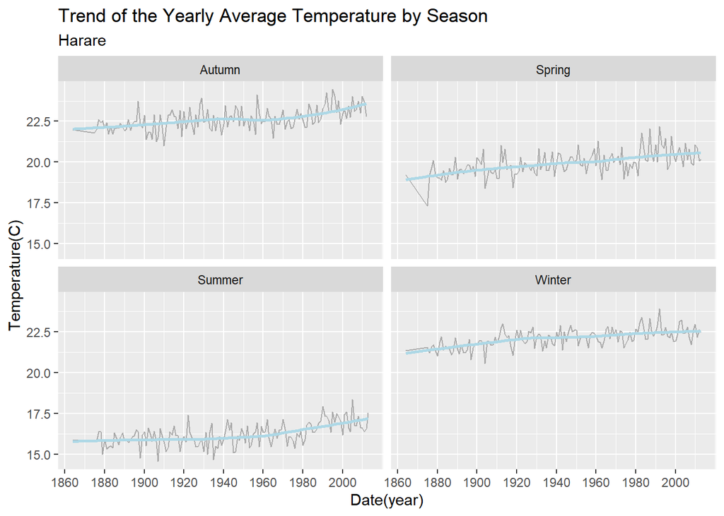

```r
city3 %>% group_by(season, year) %>% summarise(ave = mean(AverageTemperature)) %>% na.omit() %>%
  ggplot() + geom_line(col="dark grey") + aes(x=year, y=ave) + geom_smooth(col='light blue', se=F)+
  labs(title = "Trend of the Yearly Average Temperature by Season", subtitle="Harare", x= "Date(year)", y="Temperature(C)")+
  scale_x_continuous(breaks = seq(1860, 2013, 20))+
  facet_wrap(~season)
```

The capital of Zimbabwe. It was the capital of the Federation of Rhodesia and Niasaland between 1953 and 1963. The corn, Virginia tobacco, and the surrounding area of agriculture and gold mines serve as a gathering and processing area for products, and the machinery, chemical, and textiles industries are also strong. Satellite cities surround modern urban areas with high-rise buildings as the center of white culture. (Domestic)